# Homework1

Hakan Ekiz - IE360 - Fall2020

19 Kasım 2020

# Time Series Examples

Respectively, we will look to the dollar rate, the incidence of the daily cases in Turkey and to change the price of Apple’s shares

## Exchange Rates (Dollar)

The data set we are examining was taken from the CBRT. The dataset shows the monthly value of dollar against TL starting from 2004.

```r
setwd('C:/Users/Z0047JBE/Desktop/dersler/IE360/hw1/datatables')
library(data.table,quietly = TRUE)
library(ggplot2,quietly = TRUE)
library(lubridate,quietly = TRUE)
library(readxl)

dollarexchange <- read_excel('EVDS.xlsx')
setnames(dollarexchange,names(dollarexchange),c('Date', 'Months', 'Exchangerate'))
dollarexchange
```

```
## # A tibble: 203 x 3
##    Date    Months Exchangerate
##    <chr>    <dbl>        <dbl>
##  1 2004.01      1         1.34
##  2 2004.02      2         1.32
##  3 2004.03      3         1.32
##  4 2004.04      4         1.35
##  5 2004.05      5         1.50
##  6 2004.06      6         1.49
##  7 2004.07      7         1.45
##  8 2004.08      8         1.47
##  9 2004.09      9         1.50
## 10 2004.10     10         1.48
## # ... with 193 more rows
```

Dollar Exchange Rates from 2004 to 2020 by month

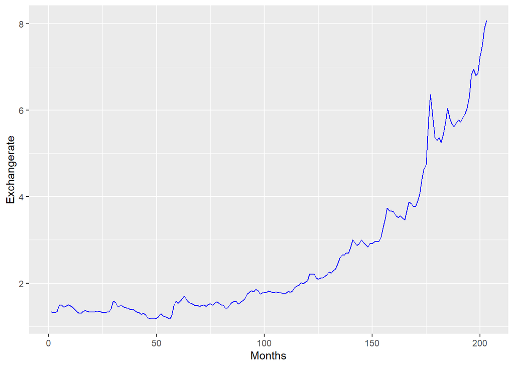

```r
graph1 <- ggplot(data=dollarexchange, aes(x=Months, y=Exchangerate))
graph1 + geom_line(color='blue')
```

Line Chart of Dollar Exchange Rates

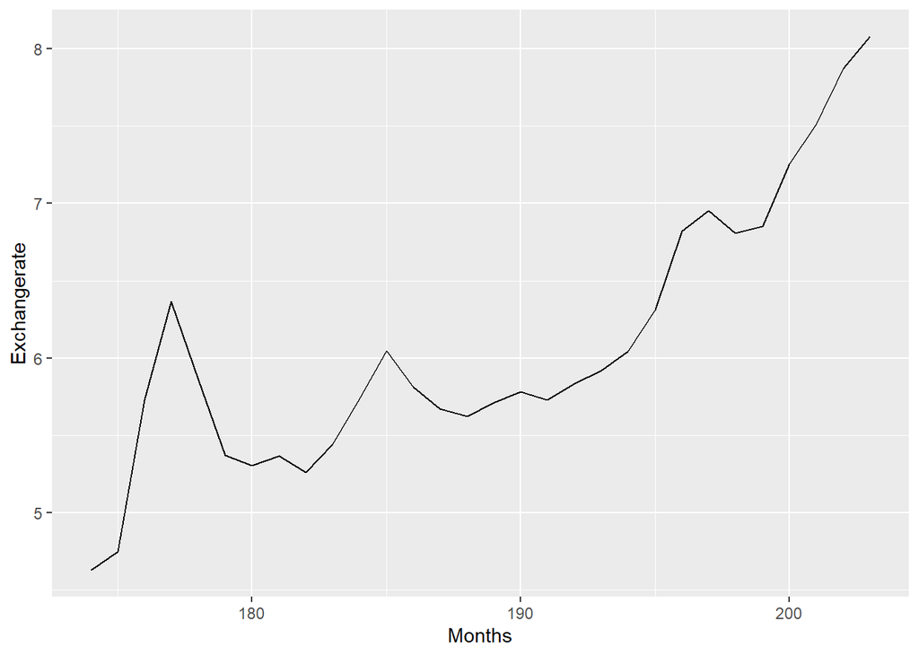

```r
ggplot(data=tail(dollarexchange,30), aes(x=Months, y=Exchangerate)) + geom_line()
```

On the other hand we will examine the data of searches for Dollar keyword in Turkey Google Trends. This data can show us a different perspective of the people in Turkey’s interest in the dollar.

```r
setwd('C:/Users/Z0047JBE/Desktop/dersler/IE360/hw1/datatables')
dollargoogletrend <- read_excel("GoogleDollar.xlsx",
    col_types = c("date", "numeric"))

setnames(dollargoogletrend,names(dollargoogletrend),c('month','view'))
dollargoogletrend
```

```
## # A tibble: 203 x 2
##    month                view
##    <dttm>              <dbl>
##  1 2004-01-01 00:00:00     1
##  2 2004-02-01 00:00:00     1
##  3 2004-03-01 00:00:00     1
##  4 2004-04-01 00:00:00     1
##  5 2004-05-01 00:00:00     1
##  6 2004-06-01 00:00:00     1
##  7 2004-07-01 00:00:00     1
##  8 2004-08-01 00:00:00     1
##  9 2004-09-01 00:00:00     1
## 10 2004-10-01 00:00:00     1
## # ... with 193 more rows
```

Google searches USD Dollar in Turkey

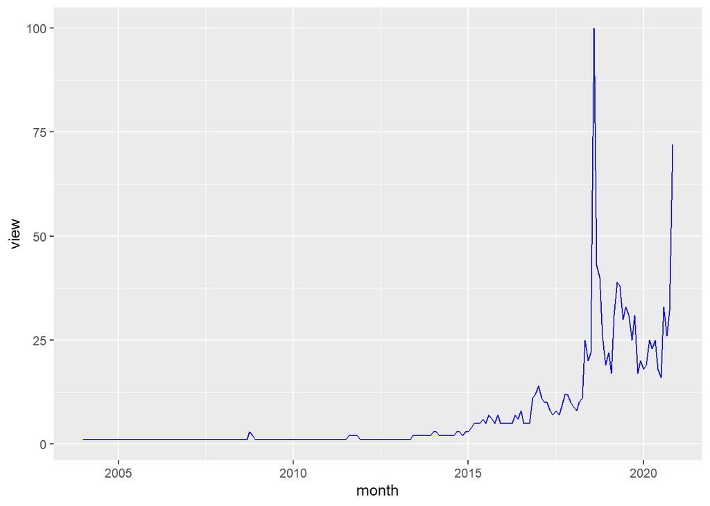

```r
graph2 <- ggplot(data=dollargoogletrend, aes(x=month, y=view))
graph2 + geom_line(color='blue')
```

Line Chart Google Searches for Dollar in Turkey

If we look at the chart above, we can say that searches have increased in the last 3 years as the dollar started to rise rapidly.

Below we can see histograms and boxplots for Dollar Exchange Rates and Google Searches for Dollar.

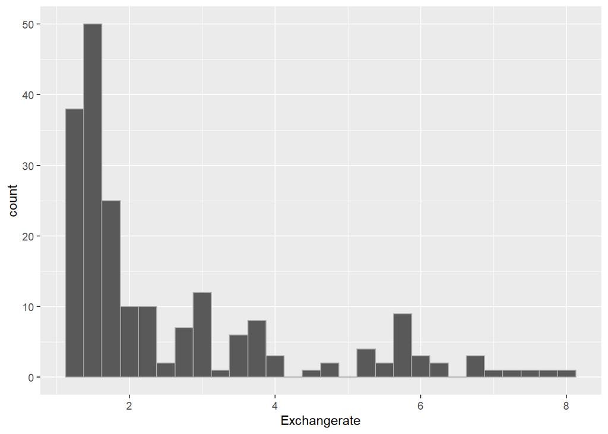

```r
graph3 <- ggplot(data=dollarexchange, aes(Exchangerate))
graph3 + geom_histogram(binwidth = 0.25, color='dark grey')
```

Histogram for USD Dollar Exchange Rate

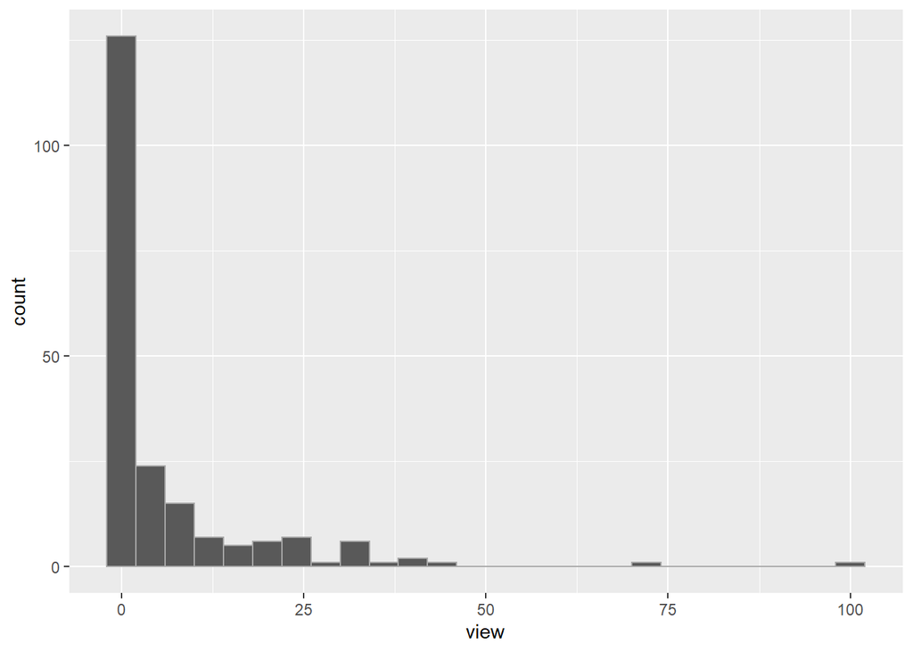

```r
graph4 <- ggplot(data=dollargoogletrend, aes(view))
graph4 + geom_histogram(binwidth = 4, color='dark grey')
```

Histogram for Google Searches

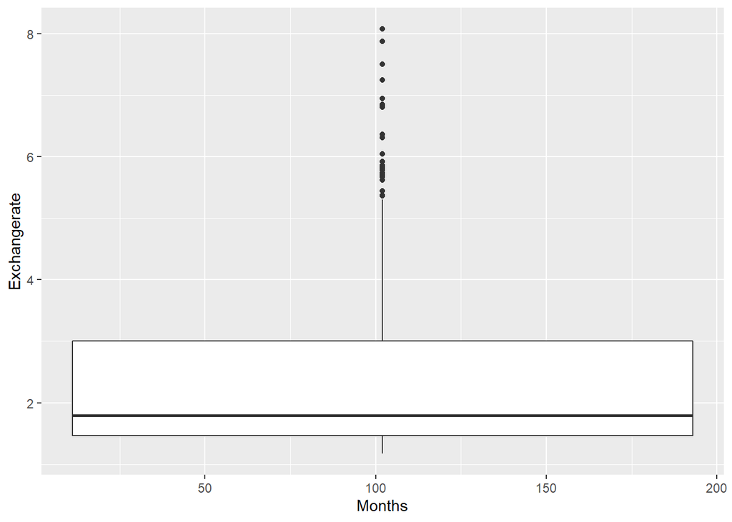

```r
graph1 <- ggplot(data=dollarexchange, aes(x=Months, y=Exchangerate))
graph1 + geom_boxplot()
```

Boxplot for USD Dollar Exchange Rate

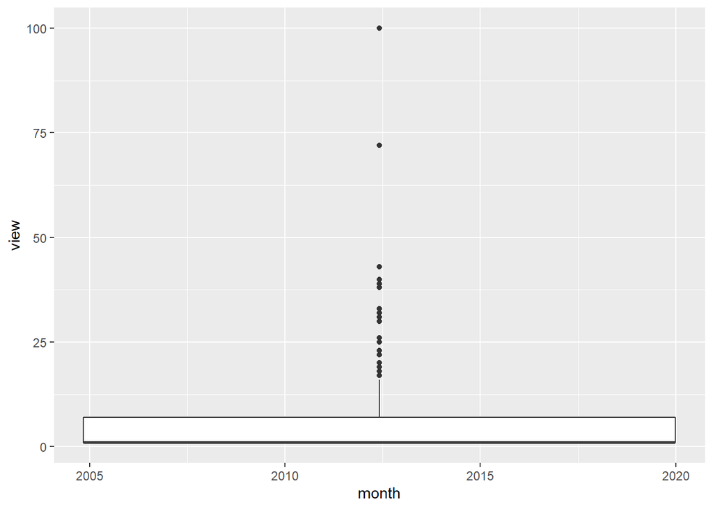

```r
graph2 <- ggplot(data=dollargoogletrend, aes(x=month, y=view))
graph2 + geom_boxplot()
```

Boxplot for Google Searches

## COVID-19

The data set is obtained here: https://www.kaggle.com/gpreda/coronavirus-2019ncov

We will review the number of cases that are mentioned daily in Turkey with this data set.

```r
setwd('C:/Users/Z0047JBE/Desktop/dersler/IE360/hw1/datatables')
covid <- read_excel('covid19.xlsx')
setnames(covid,names(covid),c('ConfirmedCases', 'DailyConfirmedCases', 'RecoveredCases','Deaths','Date'))
covid
```

```
## # A tibble: 246 x 5
##    ConfirmedCases DailyConfirmedCases RecoveredCases Deaths Date
##             <dbl>               <dbl>          <dbl>  <dbl> <dttm>
##  1             10                  10              0      0 2020-03-11 00:00:00
##  2             10                   0              0      0 2020-03-12 00:00:00
##  3             50                  40              0      0 2020-03-13 00:00:00
##  4             50                   0              0      0 2020-03-14 00:00:00
##  5             60                  10              0      0 2020-03-15 00:00:00
##  6            180                 120              0      0 2020-03-16 00:00:00
##  7            470                 290              0     10 2020-03-17 00:00:00
##  8            980                 510              0     10 2020-03-18 00:00:00
##  9           1920                 940              0     30 2020-03-19 00:00:00
## 10           3590                1670              0     40 2020-03-20 00:00:00
## # ... with 236 more rows
```

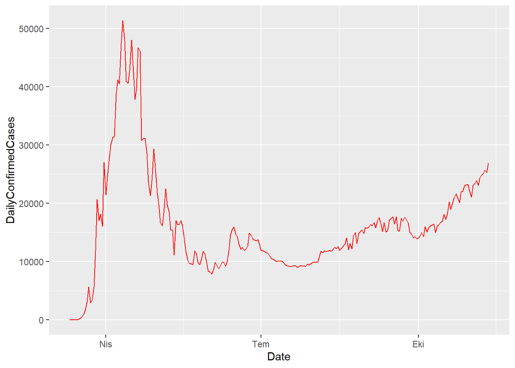

```r
graphc1 <- ggplot(data=covid, aes(x=Date, y=DailyConfirmedCases))
graphc1 + geom_line(color='red')
```

Lİne Chart (Daily Cases)

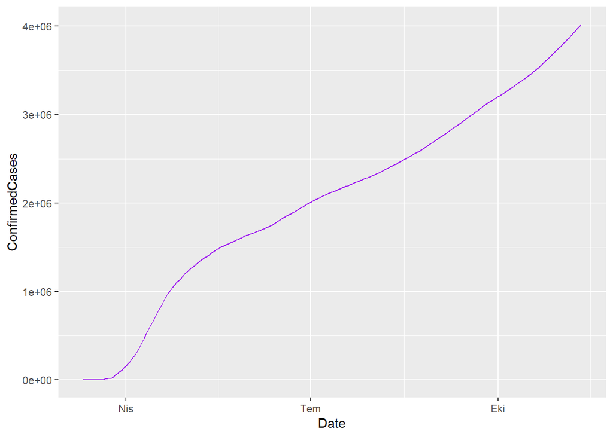

```r
graphc2 <- ggplot(data=covid, aes(x=Date, y=ConfirmedCases))
graphc2 + geom_line(color='purple')
```

LineChart (TotalCases)

In the data we have obtained from Google Trends, we will look at the searches people make for the COVID19 Vaccine.

‘COVID19 Vaccine’ Searches on Google in Turkey

```r
setwd('C:/Users/Z0047JBE/Desktop/dersler/IE360/hw1/datatables')
vaccinesearch <- read_excel('COVIDAsi.xlsx')
vaccinesearch
```

```
## # A tibble: 252 x 2
##    Date                Search
##    <dttm>               <dbl>
##  1 2020-03-10 00:00:00     11
##  2 2020-03-11 00:00:00      0
##  3 2020-03-12 00:00:00     11
##  4 2020-03-13 00:00:00     11
##  5 2020-03-14 00:00:00     13
##  6 2020-03-15 00:00:00     12
##  7 2020-03-16 00:00:00     11
##  8 2020-03-17 00:00:00      0
##  9 2020-03-18 00:00:00     16
## 10 2020-03-19 00:00:00     16
## # ... with 242 more rows
```

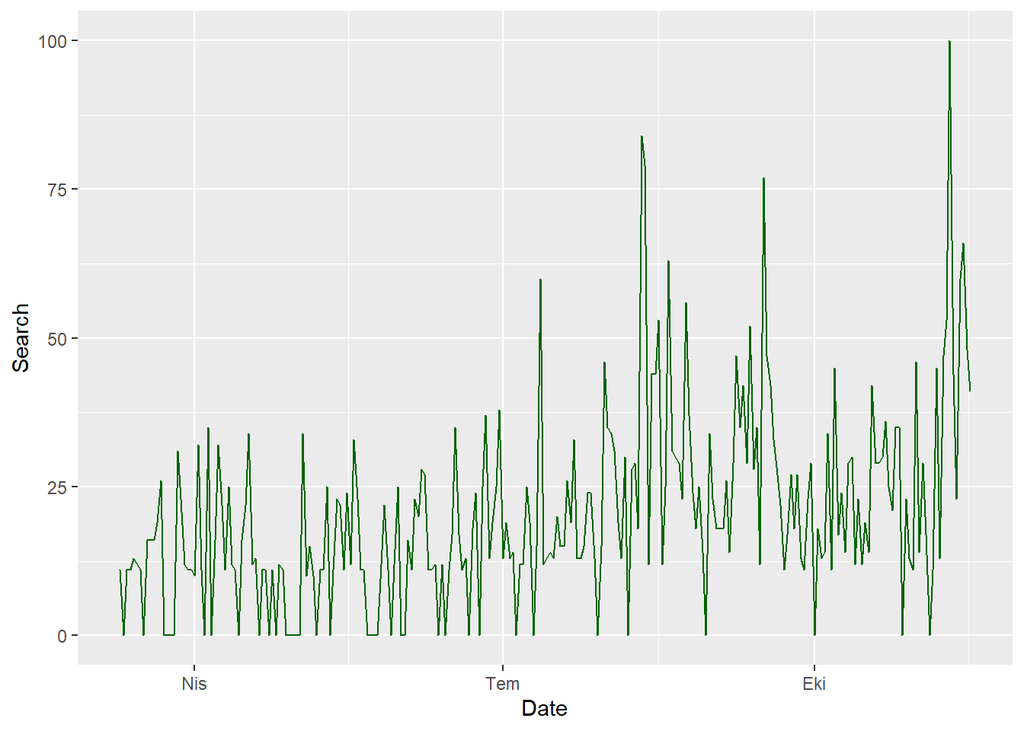

```r
graphv1 <- ggplot(data=vaccinesearch, aes(x=Date, y=Search))
graphv1 + geom_line(color='dark green')
```

Line Chart for Vaccine Google Searches in Turkey

Although the data in the chart above is fluctuating, we can observe that searches increase as time passes. We can say that the more people who have had this disease and become sick, the more people care about the disease. In addition, we can say that the peaks of the calls may have occurred as explanations about the limitation of the disease or treatment were made.

Below we can see histograms and boxplots for Daily Cases and Google Searches for COVID19 Vaccine.

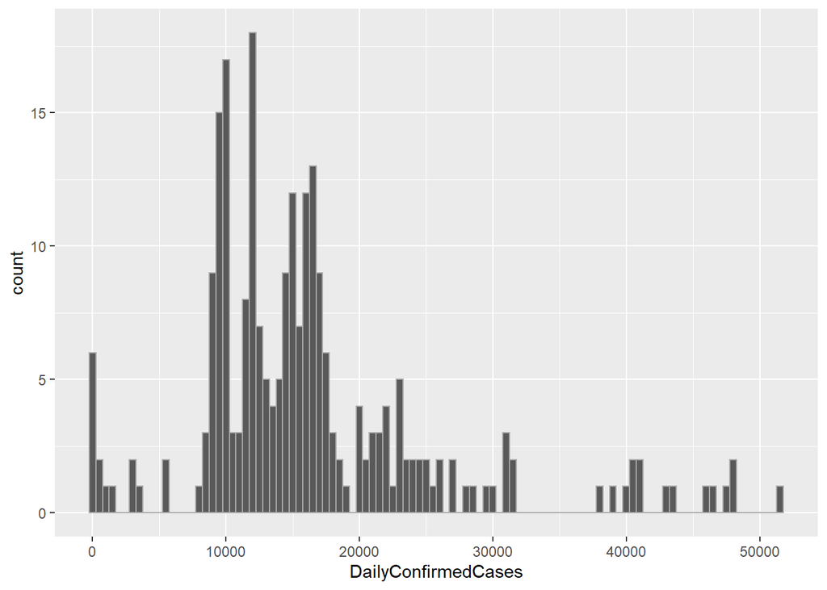

```r
graphc3 <- ggplot(data=covid, aes(DailyConfirmedCases))
graphc3 + geom_histogram(binwidth=500,color='dark grey')
```

Histogram for Daily Cases

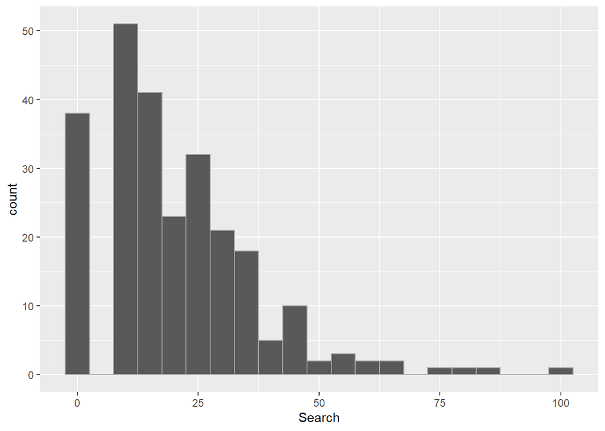

```r
graphv2 <- ggplot(data=vaccinesearch, aes(Search))
graphv2 + geom_histogram(binwidth = 5, color='dark grey')
```

Histogram for Vaccine Search

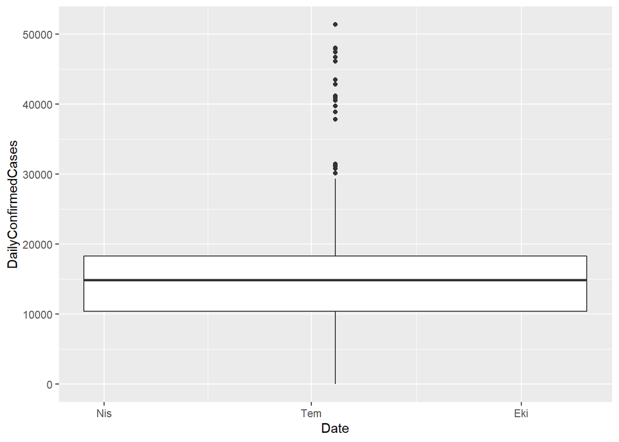

```r
graphc1 + geom_boxplot()
```

Boxplot for DailyCases

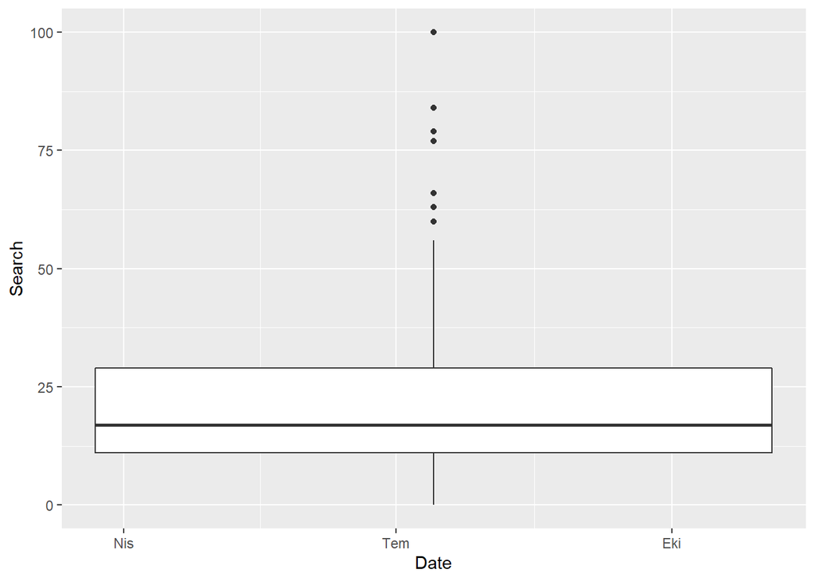

```r
graphv1 + geom_boxplot()
```

Boxplot for Vaccine Search

## Apple Stock Prices

The data set is obtained here: https://www.kaggle.com/achintyatripathi/yahoo-finance-apple-inc-aapl?select=AAPL_daily_update.csv

In this data set, we can see the daily change of Apple’s shares in the last 1 year.

Apple Share Prices

```r
setwd('C:/Users/Z0047JBE/Desktop/dersler/IE360/hw1/datatables')
stockprice <- read_excel('Applestock.xlsx')
stockprice
```

```
## # A tibble: 254 x 2
##    Date                ClosePrice
##    <dttm>                   <dbl>
##  1 2019-09-10 00:00:00   54174999
##  2 2019-09-11 00:00:00   55897499
##  3 2019-09-12 00:00:00   55772499
##  4 2019-09-13 00:00:00   54687500
##  5 2019-09-16 00:00:00   54974998
##  6 2019-09-17 00:00:00   55174999
##  7 2019-09-18 00:00:00   55692501
##  8 2019-09-19 00:00:00   55240002
##  9 2019-09-20 00:00:00   54432499
## 10 2019-09-23 00:00:00   54680000
## # ... with 244 more rows
```

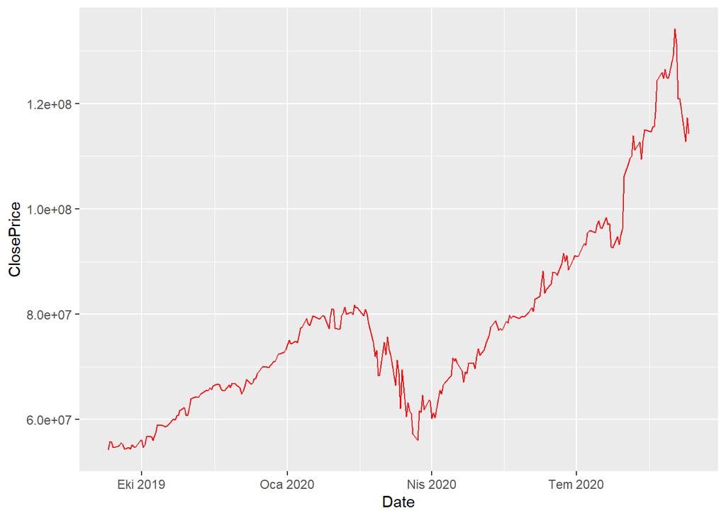

```r
grapha1 <- ggplot(data=stockprice, aes(x=Date, y=ClosePrice))
grapha1 + geom_line(color='red')
```

Line Chart of Apple Stock Price

In the chart above, we can say that stock prices have increased, except for a short period. Recently, the shares of technology companies have been increasing in general. We can also say that the pandemic started and a general uncertainty occurred for the period in which it fell.

We can say that the increase and decrease in the price of stocks is generally related to the interest of investors in those stocks.We can say that the increase and decrease in the price of stocks is generally related to the interest of investors in those stocks. We can draw an inference by looking at Google searches relevant to this interest.

Apple Search on Google all over the world

```r
setwd('C:/Users/Z0047JBE/Desktop/dersler/IE360/hw1/datatables')
applesearch <- read_excel('AppleSearch.xlsx')
applesearch
```

```
## # A tibble: 62 x 2
##    Date                Search
##    <dttm>               <dbl>
##  1 2019-09-15 00:00:00    100
##  2 2019-09-22 00:00:00     81
##  3 2019-09-29 00:00:00     52
##  4 2019-10-06 00:00:00     52
##  5 2019-10-13 00:00:00     50
##  6 2019-10-20 00:00:00     47
##  7 2019-10-27 00:00:00     50
##  8 2019-11-03 00:00:00     49
##  9 2019-11-10 00:00:00     49
## 10 2019-11-17 00:00:00     49
## # ... with 52 more rows
```

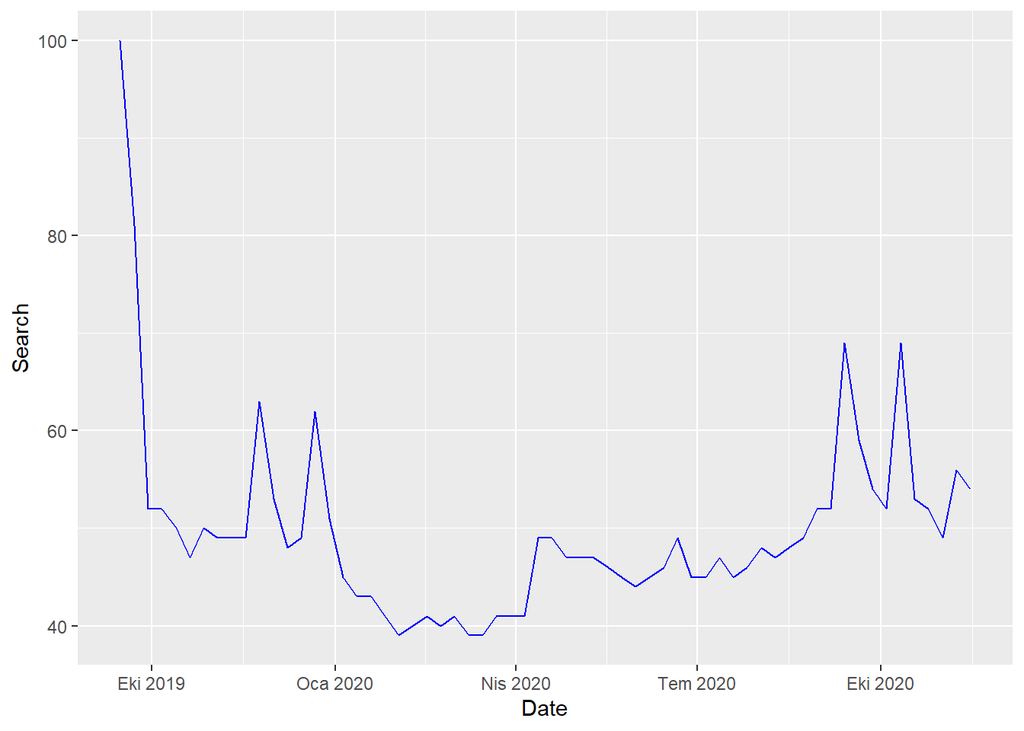

```r
graphas1 <- ggplot(data=applesearch, aes(x=Date, y=Search))
graphas1 + geom_line(color='blue')
```

Line Chart of Apple Search on Google

Below we can see histograms and boxplots for Apple Stoc Prices and Google Searches for Apple.

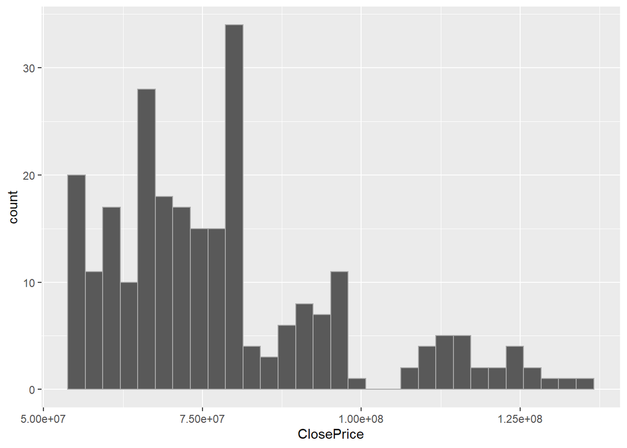

```r
grapha2 <- ggplot(data=stockprice, aes(ClosePrice))
grapha2 + geom_histogram(bins=30, color='dark grey')
```

Apple Stock Price Histogram

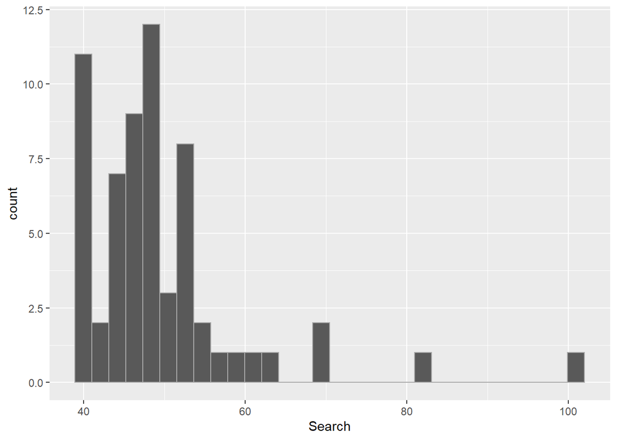

```r
graphas2 <- ggplot(data=applesearch, aes(Search))
graphas2 + geom_histogram(bins=30, color='dark grey')
```

Apple Google Search Histogram

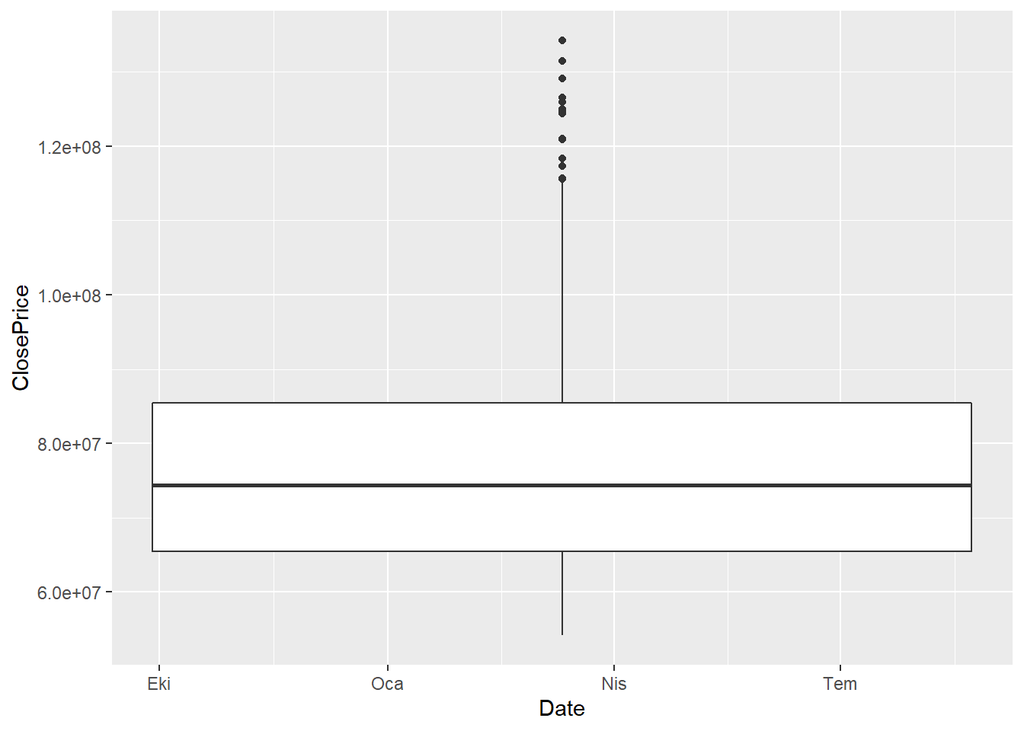

```r
grapha1 + geom_boxplot()
```

Apple Stock Price Boxplot

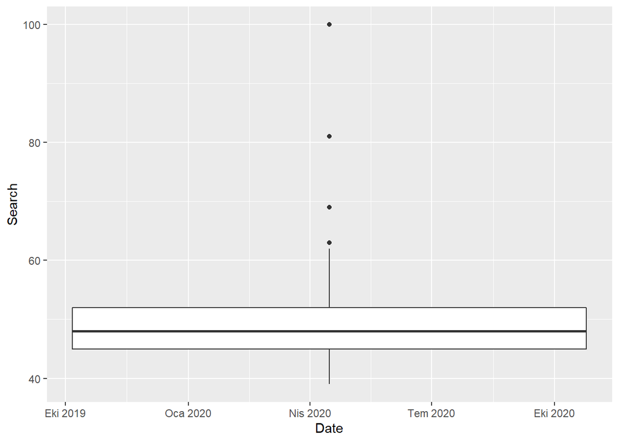

```r
graphas1 + geom_boxplot()
```

Apple Google Search Boxplot